# Statistics for biology 2019 takehome final exam Po-Chun Chen N11957611

# Q1

In a medical study, liver cellular fat content was measured by fine needle biopsy (in arbitrary units) for 18 subjects. Patient weight was measured in kg. This is in dataset weight_study.tsv.

### a. Plot the data and perform a regression analysis of this data, ignoring sex. What is the best fitting line? What proportion of variation has been explained by fitting the linear model? Would you say liver cellular fat levels can be predicted from weight?

```r
library(readr)
weight_study <- read_delim("D:/Desktop/Master_NYU/Statistics in Biology/Final/weight_study.tsv","\t", escape_double = FALSE, trim_ws = TRUE)
weight_study
```

```
## # A tibble: 18 x 3
##    WEIGHT LIVER_FAT   SEX
##     <dbl>     <dbl> <dbl>
##  1     89        28     2
##  2     88        27     2
##  3     66        25     2
##  4     59        23     2
##  5     93        29     2
##  6     73        25     2
##  7     82        29     2
##  8     77        25     2
##  9    100        30     2
## 10     67        23     2
## 11     57        29     1
## 12     68        32     1
## 13     69        35     1
## 14     59        31     1
## 15     63        29     1
## 16     59        26     1
## 17     56        28     1
## 18     66        33     1
```

Answer:

From the summary of the model, we can intepret from the Adjusted R-squared value that only -0.05639 has been explained by fitting the linear model

No, I would not say that due to the p-value the $R^2$ value.

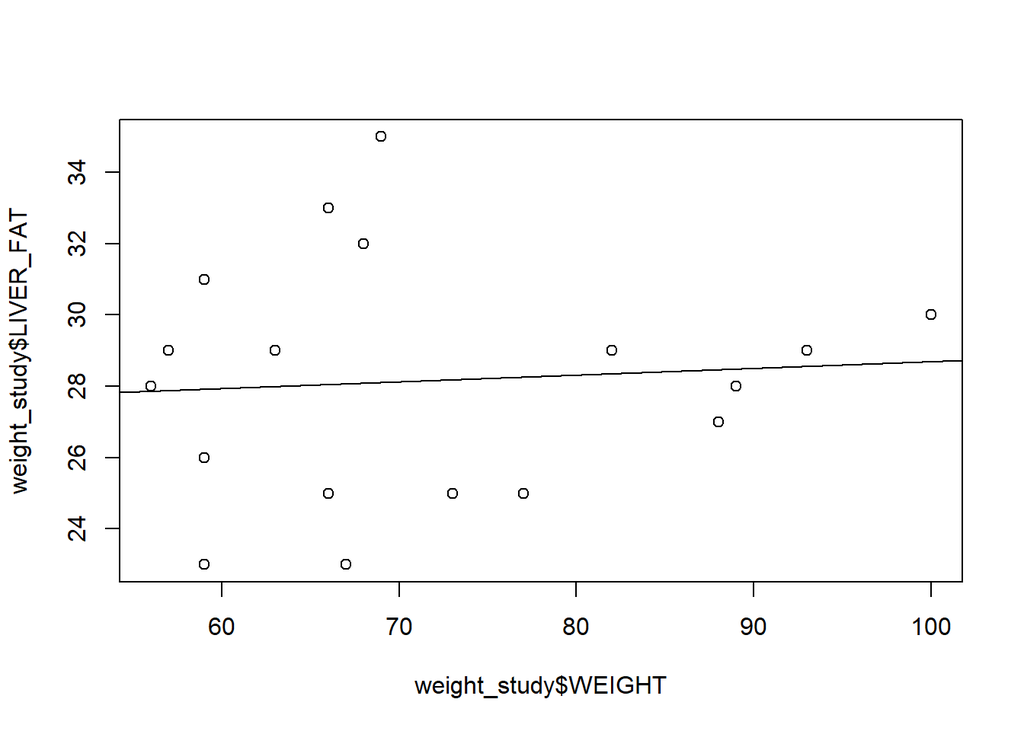

```r
plot(weight_study$WEIGHT,weight_study$LIVER_FAT)
abline(lm(weight_study$LIVER_FAT ~ weight_study$WEIGHT)) # plot the regression line
```

```r
liver_lm <- lm(weight_study$LIVER_FAT~weight_study$WEIGHT)
summary.lm(liver_lm)
```

```
##
## Call:
## lm(formula = weight_study$LIVER_FAT ~ weight_study$WEIGHT)
##
## Residuals:
##     Min      1Q  Median      3Q     Max
## -5.0782 -2.7766  0.2813  1.2548  6.8844
##
## Coefficients:
##                     Estimate Std. Error t value Pr(>|t|)
## (Intercept)         26.82238    4.49205   5.971 1.96e-05 ***
## weight_study$WEIGHT  0.01874    0.06161   0.304    0.765
## ---
## Signif. codes:  0 '***' 0.001 '**' 0.01 '*' 0.05 '.' 0.1 ' ' 1
##
## Residual standard error: 3.422 on 16 degrees of freedom
## Multiple R-squared:  0.00575,    Adjusted R-squared:  -0.05639
## F-statistic: 0.09254 on 1 and 16 DF,  p-value: 0.7649
```

```r
anova(liver_lm)
```

```
## Analysis of Variance Table
##
## Response: weight_study$LIVER_FAT
##                     Df  Sum Sq Mean Sq F value Pr(>F)
## weight_study$WEIGHT  1   1.084   1.084  0.0925 0.7649
## Residuals           16 187.416  11.713
```

### b. Now fit a model including the sex of the subjects. Note: male = 1, female = 2. Note: weight is continuous. Re-analyze the data using this new information. What are your conclusions now?

Answer:

```r
weight_study$SEX <- factor(weight_study$SEX)
str(weight_study)
```

```
## Classes 'spec_tbl_df', 'tbl_df', 'tbl' and 'data.frame': 18 obs. of  3 variables:
##  $ WEIGHT   : num  89 88 66 59 93 73 82 77 100 67 ...
##  $ LIVER_FAT: num  28 27 25 23 29 25 29 25 30 23 ...
##  $ SEX      : Factor w/ 2 levels "1","2": 2 2 2 2 2 2 2 2 2 2 ...
##  - attr(*, "spec")=
##   .. cols(
##   ..   WEIGHT = col_double(),
##   ..   LIVER_FAT = col_double(),
##   ..   SEX = col_double()
##   .. )
```

```r
liver_lm2 <- lm(weight_study$LIVER_FAT ~ weight_study$SEX + weight_study$WEIGHT)
summary.lm(liver_lm2)
```

```
##
## Call:
## lm(formula = weight_study$LIVER_FAT ~ weight_study$SEX + weight_study$WEIGHT)
##
## Residuals:
##     Min      1Q  Median      3Q     Max
## -3.7302 -0.8889 -0.2619  1.1548  3.2063
##
## Coefficients:
##                     Estimate Std. Error t value Pr(>|t|)
## (Intercept)         17.55556    2.58915   6.780 6.20e-06 ***
## weight_study$SEX2   -7.53968    1.06812  -7.059 3.88e-06 ***
## weight_study$WEIGHT  0.20635    0.04054   5.090 0.000133 ***
## ---
## Signif. codes:  0 '***' 0.001 '**' 0.01 '*' 0.05 '.' 0.1 ' ' 1
##
## Residual standard error: 1.7 on 15 degrees of freedom
## Multiple R-squared:  0.7699, Adjusted R-squared:  0.7393
## F-statistic:  25.1 on 2 and 15 DF,  p-value: 1.636e-05
```

```r
anova(liver_lm2)
```

```
## Analysis of Variance Table
##
## Response: weight_study$LIVER_FAT
##                     Df Sum Sq Mean Sq F value    Pr(>F)
## weight_study$SEX     1 70.225  70.225  24.291 0.0001819 ***
## weight_study$WEIGHT  1 74.910  74.910  25.911 0.0001330 ***
## Residuals           15 43.365   2.891
## ---
## Signif. codes:  0 '***' 0.001 '**' 0.01 '*' 0.05 '.' 0.1 ' ' 1
```

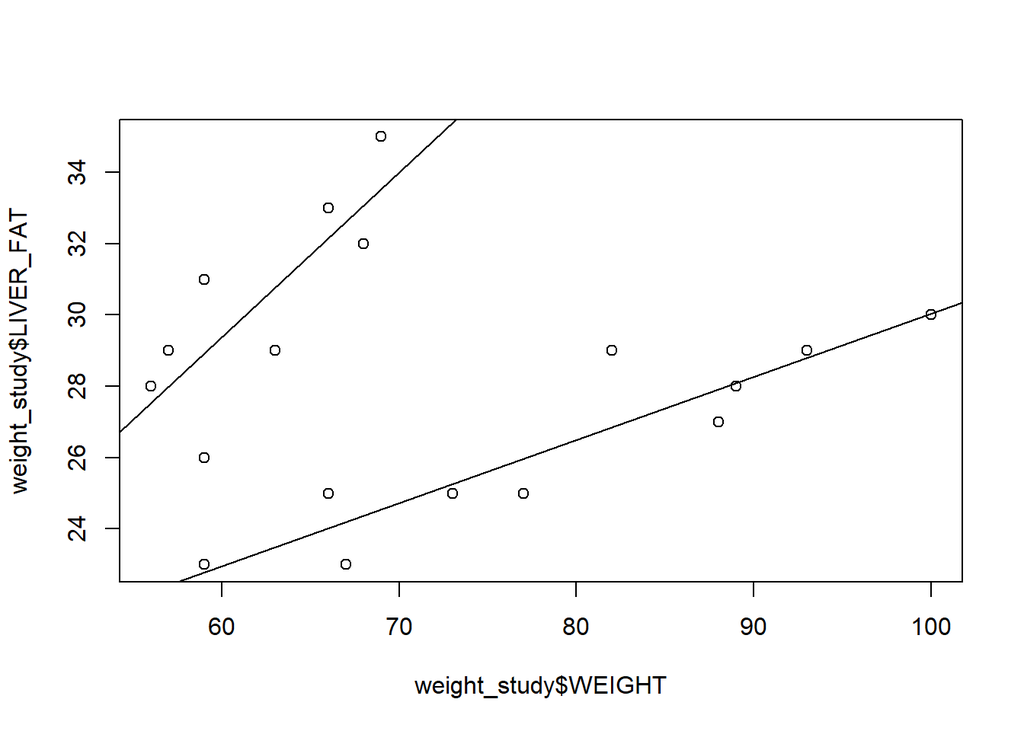

```r
plot(weight_study$WEIGHT,weight_study$LIVER_FAT)
weight_1 <- weight_study[weight_study$SEX=='1',]
weight_2 <- weight_study[weight_study$SEX=='2',]
lm_1 <- lm(weight_1$LIVER_FAT~ weight_1$WEIGHT)
lm_2 <- lm(weight_2$LIVER_FAT~ weight_2$WEIGHT)
abline(lm_1)
abline(lm_2)
```

# Q2

In the dataset “potassium_drug.csv” is the result of of study of two drugs (Drug1 and Drug2) given to mice with the serum potassium levels measured (in mmol/L) after giving the drugs.Drug1 was given at a low dose and at a mid-range dose; Drug2 was either given or not.

We want to know whether giving these drugs together is safe, or do they affect each others’ response? The experimental design was balanced and included every combination of the two drugs.

### What kind of experimental design is this?

Answer:

This is a factorial design, and a two-way anova.

### Analyze this dataset, including a plot useful to answer the biological question posed above.

```r
library(readr)
potassium_drug <- read_csv("D:/Desktop/Master_NYU/Statistics in Biology/Final/potassium_drug.csv")
anova(lm(potassium_drug$serum_potassium~potassium_drug$Drug1*potassium_drug$Drug2))
```

```
## Analysis of Variance Table
##
## Response: potassium_drug$serum_potassium
##                                           Df  Sum Sq Mean Sq F value   Pr(>F)
## potassium_drug$Drug1                       1    89.0   88.97  0.3741 0.543096
## potassium_drug$Drug2                       1  1512.2 1512.18  6.3579 0.014360
## potassium_drug$Drug1:potassium_drug$Drug2  1  2617.0 2616.96 11.0029 0.001549
## Residuals                                 60 14270.5  237.84
##
## potassium_drug$Drug1
## potassium_drug$Drug2                      *
## potassium_drug$Drug1:potassium_drug$Drug2 **
## Residuals
## ---
## Signif. codes:  0 '***' 0.001 '**' 0.01 '*' 0.05 '.' 0.1 ' ' 1
```

```r
str(potassium_drug)
```

```
## Classes 'spec_tbl_df', 'tbl_df', 'tbl' and 'data.frame': 64 obs. of  3 variables:
##  $ Drug1          : chr  "low" "low" "low" "low" ...
##  $ Drug2          : chr  "minus" "minus" "minus" "minus" ...
##  $ serum_potassium: num  9.41 34.47 46.67 16.64 24.38 ...
##  - attr(*, "spec")=
##   .. cols(
##   ..   Drug1 = col_character(),
##   ..   Drug2 = col_character(),
##   ..   serum_potassium = col_double()
##   .. )
```

```r
potassium_drug$Drug1 <- as.factor(potassium_drug$Drug1)
potassium_drug$Drug2 <- as.factor(potassium_drug$Drug2)
```

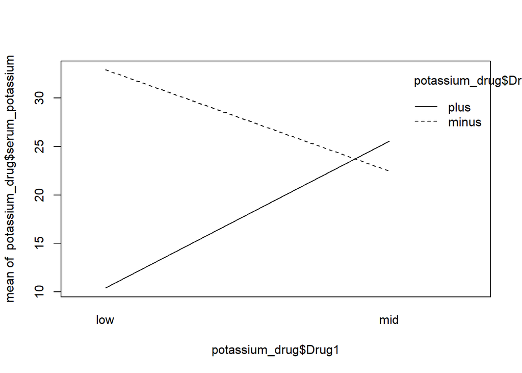

```r
interaction.plot(potassium_drug$Drug1,potassium_drug$Drug2,potassium_drug$serum_potassium)
```

```r
library(lsr)
etaSquared(lm(potassium_drug$serum_potassium~potassium_drug$Drug1*potassium_drug$Drug2))
```

```
##                                                eta.sq eta.sq.part
## potassium_drug$Drug1                      0.004812326 0.006196132
## potassium_drug$Drug2                      0.081789895 0.095812689
## potassium_drug$Drug1:potassium_drug$Drug2 0.141544013 0.154964262
```

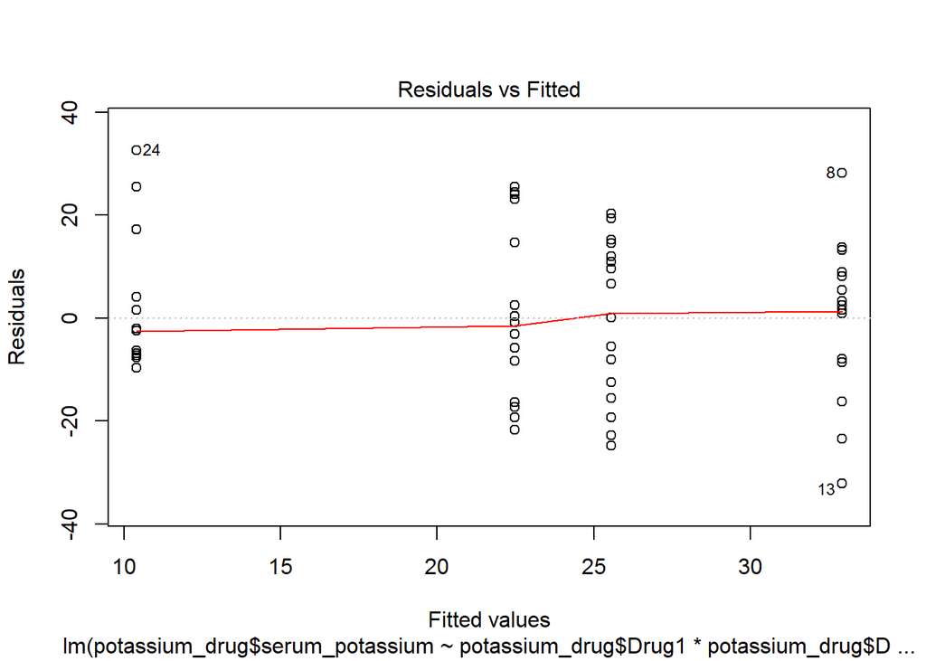

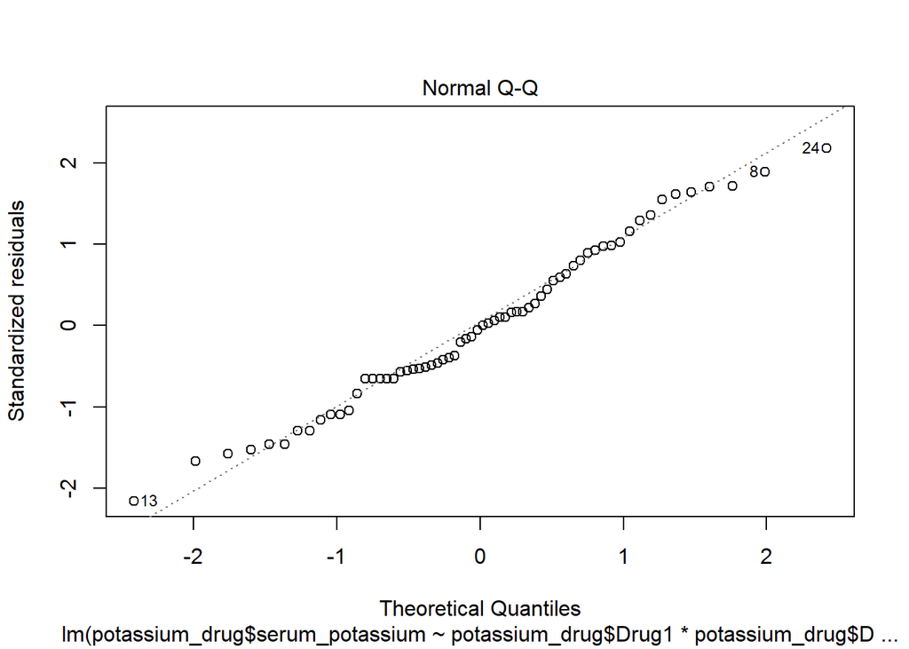

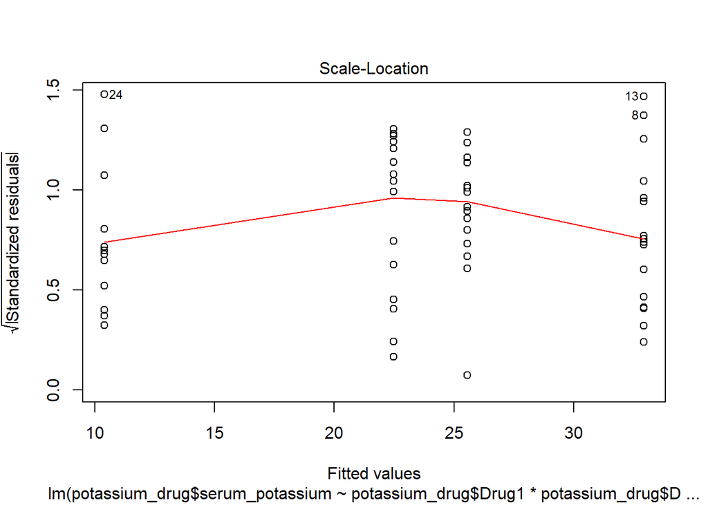

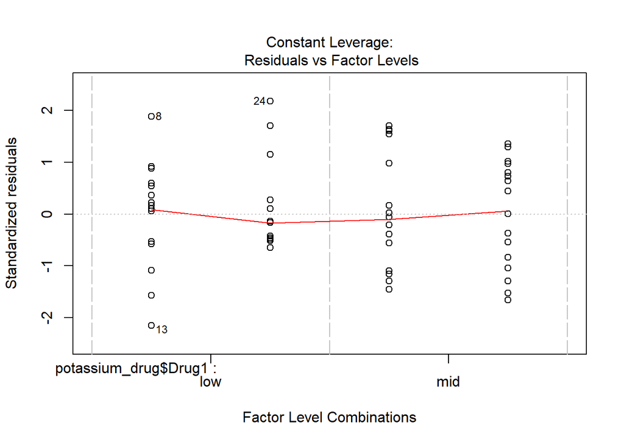

```r
plot(lm(potassium_drug$serum_potassium~potassium_drug$Drug1*potassium_drug$Drug2))
```

### What is your answer to the biological question posed? Show appropriate plots (including diagnostic plots), effect sizes, and p-values to support your conclusion.

Answer:

We want to know whether giving these drugs together is safe, or do they affect each others’ response?

From the interaction plot and the p-value (0.001549) shown above, we can conclude that there is an interaction between drugs. So, it is not safe to take drugs that will affect each other. As for the effect size, the interaction term’s potassium_drug Drug1:potassium_drug Drug2 is also larger than either drug alone. Therefore, we can further confirm.

# Q3

In the dataset “mouse.tsv”, three experimental treatments were administered to mice, and the glycogen content of the mice’ livers was analysed as the response variable. There were two mice per treatment, so the total number of mice was n = 3 × 2 = 6 mice. After each mouse was killed, its liver was cut up into three pieces: a left-hand bit, a central bit and a right-hand bit. Finally, two separate preparations were made from each macerated bit of liver, to assess the measurement error associated with the analytical machinery.

### What is the null hypothesis?

Ans: There is no difference of glycogen levels between the three treatments

### How many *independent* units were assignment to treatments?

Ans: 6 independent biological replicates i.e. mice

### What is the expected residual or error degrees of freedom?

Answer:

The expected residual or error degrees of freedom is 3 in this case.

Note we expect error dof 6 mices-3 groups = 3.

### Analyse this data to test whether any of the treatments differ, using the simplest model possible.

```r
library(readr)
mouse <- read_delim("mouse.tsv", "\t", escape_double = FALSE, trim_ws = TRUE)
str(mouse)
```

```
## Classes 'spec_tbl_df', 'tbl_df', 'tbl' and 'data.frame': 36 obs. of  4 variables:
##  $ Glycogen : num  131 130 131 125 136 142 150 148 140 143 ...
##  $ Treatment: num  1 1 1 1 1 1 1 1 1 1 ...
##  $ Mouse    : num  1 1 1 1 1 1 2 2 2 2 ...
##  $ Liver    : num  1 1 2 2 3 3 1 1 2 2 ...
##  - attr(*, "spec")=
##   .. cols(
##   ..   Glycogen = col_double(),
##   ..   Treatment = col_double(),
##   ..   Mouse = col_double(),
##   ..   Liver = col_double()
##   .. )
```

```r
mouse$Treatment <- as.factor(mouse$Treatment)
mouse$Mouse <- as.factor(mouse$Mouse)
mouse$Liver <- as.factor(mouse$Liver)
str(mouse)
```

```
## Classes 'spec_tbl_df', 'tbl_df', 'tbl' and 'data.frame': 36 obs. of  4 variables:
##  $ Glycogen : num  131 130 131 125 136 142 150 148 140 143 ...
##  $ Treatment: Factor w/ 3 levels "1","2","3": 1 1 1 1 1 1 1 1 1 1 ...
##  $ Mouse    : Factor w/ 2 levels "1","2": 1 1 1 1 1 1 2 2 2 2 ...
##  $ Liver    : Factor w/ 3 levels "1","2","3": 1 1 2 2 3 3 1 1 2 2 ...
##  - attr(*, "spec")=
##   .. cols(
##   ..   Glycogen = col_double(),
##   ..   Treatment = col_double(),
##   ..   Mouse = col_double(),
##   ..   Liver = col_double()
##   .. )
```

```r
mouse
```

```
## # A tibble: 36 x 4
##    Glycogen Treatment Mouse Liver
##       <dbl> <fct>     <fct> <fct>
##  1      131 1         1     1
##  2      130 1         1     1
##  3      131 1         1     2
##  4      125 1         1     2
##  5      136 1         1     3
##  6      142 1         1     3
##  7      150 1         2     1
##  8      148 1         2     1
##  9      140 1         2     2
## 10      143 1         2     2
## # … with 26 more rows
```

```r
# correct approach 1: single summary i.e. take mean
tt_mouse<-as.numeric(mouse$Treatment)
cv_mouse<-tapply(mouse$Glycogen,list(mouse$Treatment,mouse$Mouse),mean)
#cv_mouse
cv_mouse <- as.vector(cv_mouse)
tv_mouse<-tapply(tt_mouse,list(mouse$Treatment,mouse$Mouse),mean)
tv_mouse<-factor(as.vector(tv_mouse))
#cv_mouse
#tv_mouse
model2<-lm(cv_mouse~tv_mouse)
summary(model2)
```

```
##
## Call:
## lm(formula = cv_mouse ~ tv_mouse)
##
## Residuals:
##       1       2       3       4       5       6
## -8.0000 -1.3333 -0.8333  8.0000  1.3333  0.8333
##
## Coefficients:
##             Estimate Std. Error t value Pr(>|t|)
## (Intercept)  140.500      4.707  29.848 8.26e-05 ***
## tv_mouse2     10.500      6.657   1.577    0.213
## tv_mouse3     -5.333      6.657  -0.801    0.482
## ---
## Signif. codes:  0 '***' 0.001 '**' 0.01 '*' 0.05 '.' 0.1 ' ' 1
##
## Residual standard error: 6.657 on 3 degrees of freedom
## Multiple R-squared:  0.6613, Adjusted R-squared:  0.4355
## F-statistic: 2.929 on 2 and 3 DF,  p-value: 0.1971
```

```r
anova(model2)
```

```
## Analysis of Variance Table
##
## Response: cv_mouse
##           Df Sum Sq Mean Sq F value Pr(>F)
## tv_mouse   2 259.59 129.796   2.929 0.1971
## Residuals  3 132.94  44.315
```

### What model assumption that can affect p-value interpretation did you need to correct for in this solution?

Answer:

The question is a nested design which means that the liver is nested within mice. Therefore, we can not use one way anova. The correct way is to remove the pseudo replication and analyze the data with nested anova.

From the p-value shown in the model after taking mean and the TukeyHSD method, we can not reject the null hypothesis due to high p-value. Therefore, there is no significant result between treatments.

```r
TukeyHSD(aov(model2))
```

```
##   Tukey multiple comparisons of means
##     95% family-wise confidence level
##
## Fit: aov(formula = model2)
##
## $tv_mouse
##           diff       lwr      upr     p adj
## 2-1  10.500000 -17.31776 38.31776 0.3787197
## 3-1  -5.333333 -33.15110 22.48443 0.7281783
## 3-2 -15.833333 -43.65110 11.98443 0.1862260
```

# Q4

Consider a study in which the random outcome for each individual $i$ is $Z_i\in\{0,1\}$, where $Z=1$ codes for a positive outcome and $Z=0$ codes for a negative outcome. The explanatory variables, $X$ and $Y$ affect the probability that $Z=1$, and there may be an interaction between $X$ and $Y$, modeled as a product $XY$ term. The data are in the file “log.reg.data.txt”. (Note that the off-diagonal elements in the confusion matrix were mislabeled in the original LogisticRegressionExpoAndDemo.rmd and .pdf files, but the updated and posted files, LogisticRegressionExpoAndDemo2.rmd and .pdf are correct.)

### a. Perform logistic regression analysis on a “training” part of the log.reg.data data frame consisting of the first 500 rows, and reserve the remaining 500 rows for testing the model. Start with a full model including explanatory variables X, Y, and a multiplicative interaction term. Apply the summary function to the output of your call to the glm function, and report its output.

```r
log.reg.data <- read.csv("D:/Desktop/Master_NYU/Statistics in Biology/Final/log.reg.data.txt", sep="")
#View(log.reg.data)
train <- log.reg.data[1:500,]
train_glm <- glm(Z ~ 1+X+ Y + train$Y:train$X, family = binomial(link = "logit"),data=train)
summary(train_glm)
```

```
##
## Call:
## glm(formula = Z ~ 1 + X + Y + train$Y:train$X, family = binomial(link = "logit"),
##     data = train)
##
## Deviance Residuals:
##     Min       1Q   Median       3Q      Max
## -2.1776  -0.7942  -0.4313   0.8707   2.3513
##
## Coefficients:
##                 Estimate Std. Error z value Pr(>|z|)
## (Intercept)     -2.69923    0.43035  -6.272 3.56e-10 ***
## X                0.27929    0.07213   3.872 0.000108 ***
## Y                0.37100    0.16011   2.317 0.020497 *
## train$Y:train$X  0.05475    0.03049   1.796 0.072496 .
## ---
## Signif. codes:  0 '***' 0.001 '**' 0.01 '*' 0.05 '.' 0.1 ' ' 1
##
## (Dispersion parameter for binomial family taken to be 1)
##
##     Null deviance: 688.53  on 499  degrees of freedom
## Residual deviance: 523.22  on 496  degrees of freedom
## AIC: 531.22
##
## Number of Fisher Scoring iterations: 4
```

### b. Simplify the model and explain the reason for the simplification if it is warranted. Use the p-values of the terms in the summary function above to decide. If you decide to simplify, run your simplified model on the same (test) data. Report the summary as above.

```r
train_glm2 <- glm(Z ~ X+Y,family = binomial (link = "logit"),data = train)
summary(train_glm2)
```

```
##
## Call:
## glm(formula = Z ~ X + Y, family = binomial(link = "logit"), data = train)
##
## Deviance Residuals:
##     Min       1Q   Median       3Q      Max
## -2.0416  -0.8490  -0.3698   0.8675   2.5731
##
## Coefficients:
##             Estimate Std. Error z value Pr(>|z|)
## (Intercept) -3.27317    0.32176 -10.173  < 2e-16 ***
## X            0.38928    0.04241   9.180  < 2e-16 ***
## Y            0.62488    0.08260   7.565 3.87e-14 ***
## ---
## Signif. codes:  0 '***' 0.001 '**' 0.01 '*' 0.05 '.' 0.1 ' ' 1
##
## (Dispersion parameter for binomial family taken to be 1)
##
##     Null deviance: 688.53  on 499  degrees of freedom
## Residual deviance: 526.49  on 497  degrees of freedom
## AIC: 532.49
##
## Number of Fisher Scoring iterations: 4
```

### c. Use your model (created with the training data) to estimate the probability—call it pr.test—that Z=1 for each individual in the test set (rows 501–1000 of log.reg.data). Use your pr.test values and observed Z values in your test data set to make an ROC plot, and compute the area under the curve (AUC). Use the function in the library or the identical function in the final exam folder (don’t forget to source the .R file).

```r
train_glm2
```

```
##
## Call:  glm(formula = Z ~ X + Y, family = binomial(link = "logit"), data = train)
##
## Coefficients:
## (Intercept)            X            Y
##     -3.2732       0.3893       0.6249
##
## Degrees of Freedom: 499 Total (i.e. Null);  497 Residual
## Null Deviance:       688.5
## Residual Deviance: 526.5     AIC: 532.5
```

```r
test <- log.reg.data[501:1000,]
#test
pr<-predict(train_glm2,newdata = test,type="response")
#pr

library(asbio)
```

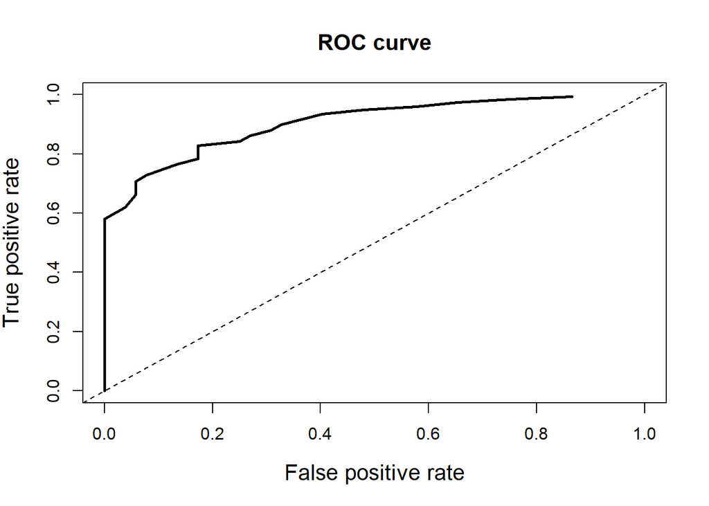

```
## [1] 0.8986951
```

```r
auc(test$Z,pr,plot=TRUE)
```

### d. Convert your pr.test values to a predicted event status (0 or 1) using a threshold probability value of 0.5. Construct a confusion matrix. Use its entries to compute Recall, Precision, Accuracy, and True Negative Rate.

```r
pr<- ifelse(pr>0.5, 1, 0)
#pr
conf.mat<-table(pr,test$Z)
conf.mat
```

```
##
## pr    0   1
##   0   7   3
##   1  45 445
```

```r
TN<-conf.mat[1,1]
FN<-conf.mat[1,2]
FP<-conf.mat[2,1]
TP<-conf.mat[2,2]
recall<-TP/(TP+FN)
recall
```

```
## [1] 0.9933036
```

```r
precision<-TP/(TP+FP)
precision
```

```
## [1] 0.9081633
```

```r
accuracy<-(TP+TN)/(TP+TN+FP+FN)
accuracy
```

```
## [1] 0.904
```

```r
TNR<-TN/(TN+FP)
TNR
```

```
## [1] 0.1346154
```

# Q5

Three new sequencing libraries have become available for the yeast growth rate and RNA expression study. The normalized count data (not on a log scale) are in the data file “YeastRNAnew.txt.”" The 3 columns with labels C12d, C20d, and C30d, each add one more replicate to Carbon limited growth at rates of 0.12, 0.20 and 0.30 per hour per cell. The original data from the Dec 2 class are in data file “NormalizedYeastRNAGrowthRateStudy.txt”

### a. Combine these data into one data frame or matrix, and organize the columns such that the C12a-d come first, followed by C20a-d, followed by C30a-d.

```r
NormalizedYeastRNAGrowthRateStudy <- read.csv("D:/Desktop/Master_NYU/Statistics in Biology/Final/NormalizedYeastRNAGrowthRateStudy.txt", sep="")
ThreeNewYeastLibraries <- read.csv("D:/Desktop/Master_NYU/Statistics in Biology/Final/ThreeNewYeastLibraries.txt", sep="")

combine_yeast <- cbind(NormalizedYeastRNAGrowthRateStudy,ThreeNewYeastLibraries)

combine_yeast_new <- combine_yeast[,c("C12a", "C12b", "C12c","C12d","C20a", "C20b", "C20c","C20d","C30a", "C30b", "C30c","C30d")]
head(combine_yeast_new)
```

```
##                 C12a       C12b       C12c       C12d       C20a       C20b
## TEL01L-XR 0.15975304 0.52213574 0.30523068 0.30523068 0.11431285 0.08731094
## YAL069W   0.06050565 0.06553958 0.14289689 0.06553958 0.05688266 0.02645938
## TEL01L-XC 0.09291703 0.08543464 0.20203326 0.09291703 0.08243632 0.04261294
## ARS102    0.07584177 0.02727682 0.12522673 0.07584177 0.06331402 0.05688266
## YAL068C   0.05688266 0.02645938 0.16610775 0.05688266 0.08265896 0.04658637
## YAL067W-A 0.07981519 0.04261294 0.04717254 0.04717254 0.06553958 0.06331402
##                 C20c       C20d       C30a       C30b       C30c       C30d
## TEL01L-XR 0.11800747 0.11431285 0.12526953 0.18179026 0.29239463 0.18179026
## YAL069W   0.02683773 0.02683773 0.08265896 0.04658637 0.04261294 0.04658637
## TEL01L-XC 0.02727682 0.04261294 0.12749509 0.06331402 0.05688266 0.06331402
## ARS102    0.02645938 0.05688266 0.08879324 0.08265896 0.04658637 0.08265896
## YAL068C   0.04261294 0.04658637 0.02727682 0.06553958 0.06331402 0.06331402
## YAL067W-A 0.05688266 0.06331402 0.02645938 0.02683773 0.08265896 0.02683773
```

### b. Carry out principal components analysis on the enlarged set of expression libraries, as done in the in-class demonstration, beginning with the transpose operation and log transformation of the data. What proportion of the total variance is accounted for by the first and second principal components?

Answer: 70.56% of the total variance is accounted for by the first and second principal components

```r
combine_yeast_new_T <- t(combine_yeast_new)
combine_yeast_new_T <- log(combine_yeast_new_T)


gout_yeast <- prcomp(combine_yeast_new_T)
gout.sum <- summary(gout_yeast)
gout.sum
```

```
## Importance of components:
##                            PC1     PC2      PC3      PC4     PC5     PC6    PC7
## Standard deviation     32.5147 14.7470 11.86636 10.01488 9.16046 8.30893 7.7089
## Proportion of Variance  0.5853  0.1204  0.07795  0.05552 0.04645 0.03822 0.0329
## Cumulative Proportion   0.5853  0.7056  0.78360  0.83912 0.88557 0.92379 0.9567
##                            PC8     PC9    PC10    PC11     PC12
## Standard deviation     7.27755 3.31261 2.85963 2.47418 2.85e-14
## Proportion of Variance 0.02932 0.00607 0.00453 0.00339 0.00e+00
## Cumulative Proportion  0.98601 0.99208 0.99661 1.00000 1.00e+00
```

### c. Compute the scores matrix (PrincipalComponents-by-Libraries). Create a plot of the scores (or coefficients or weights) of the second principal component versus the scores of the first principal component. Do the 3 new libraries seem to be in accord with the previous 9 with regard to the groupings of growth rates in the biplot?

Answer: Yes, from the biplot. The 3 new libraries seem to be in accord with the previous 9 with regard to the groupings of growth rates.

```r
scores.pc<-t(gout_yeast$rotation)%*%t(combine_yeast_new_T-gout_yeast$center)
scores.pc
```

```
##             C12a        C12b       C12c         C12d       C20a       C20b
## PC1   34.5706086  37.1443272  43.174267  37.99932212  66.898742  68.120486
## PC2  -70.6241247 -64.7116358 -47.554089 -62.84152490 -80.737215 -96.558334
## PC3   12.7552156   8.9677327  16.162052  11.53464731  17.410515   8.739737
## PC4    4.0292667   0.4626699  18.612733   6.61811334  23.698566  15.536256
## PC5   -7.9950031  -8.4972472   0.284815  -6.51091927  -5.127014  10.331442
## PC6    7.9166984  -0.8383466  -9.796354  -0.45751415 -18.457725   6.990385
## PC7  -17.3975909 -27.1120852  -1.205405 -13.94417688 -23.785374 -10.421382
## PC8    0.8325003 -27.2767215 -11.924430 -13.65354128  -9.400095 -16.318510
## PC9   -3.2012810  -5.2833125  -4.596077  -5.22151709  -8.450646  -5.748713
## PC10  14.6093278  11.4361496  10.910731  13.28977895  13.779974  12.559593
## PC11  -7.9222233  -9.5693828  -6.448677   0.69396055  -7.469230  -7.091149
## PC12  -1.9645692  -0.9942233  -2.811155  -0.06845051  -1.673613   3.697521
##            C20c       C20d       C30a         C30b        C30c        C30d
## PC1   72.292547  71.361216 108.893338 119.64336468 116.6250744 113.9985700
## PC2  -88.755805 -92.118689 -60.576716 -63.54173725 -62.6985414 -65.1455504
## PC3   21.056175  15.206405  27.436783  28.61352612 -17.7660047  12.6991136
## PC4   -9.318287   7.707118  -8.071345  18.70214723   4.7654059   3.2004539
## PC5  -20.628171  -7.797848  12.721817 -16.67134532  -6.0996392  -3.1626821
## PC6  -11.297220  -8.969311  -7.880024   9.83778357  -4.5409511  -0.7680577
## PC7   -3.024472 -14.788838 -16.428293 -18.87422937 -15.2950649 -22.4379312
## PC8  -12.384956 -12.148417 -10.236486 -10.83454914  -7.3123853 -12.5004192
## PC9   -7.005546  -3.194799  -8.773205 -11.56853291  -7.5660740   2.7372580
## PC10  16.255777   4.462597  10.959617  14.34153685  10.0782391  12.8285147
## PC11  -6.073743  -6.505493  -6.489502  -6.25001422  -4.4776917  -7.2314360
## PC12   3.518585   2.552861  -1.315057  -0.08046205   0.4537474  -1.3454702
```

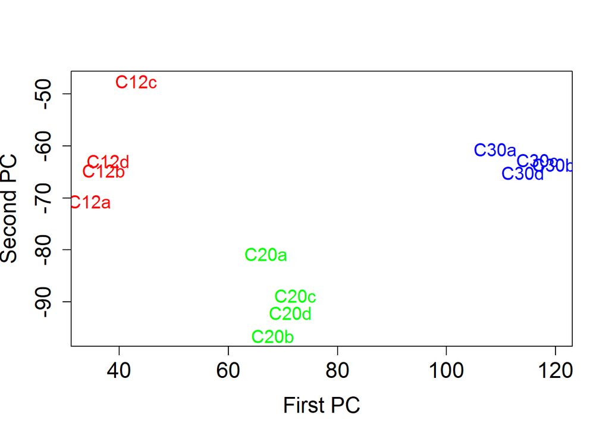

```r
plot(scores.pc[1,],scores.pc[2,],type="n",xlab="First PC",ylab="Second PC",cex.axis=1.5,cex.lab=1.5)
text(scores.pc[1,],scores.pc[2,],labels=as.character(colnames(scores.pc)),cex=1.25,col=rep(c("red","green","blue"),c(4,4,4)))
```

### d. Explore the results of performing principal components analysis of the data on a linear scale rather than a logarithmic scale; i.e., without taking the log of the data. What fraction of the total variance is accounted for by the first 2 principal components? How does the biplot for the linear scale expression data differ from that for the logarithmic data with respect to grouping of the libraries according to growth rate?

Answer:

85.52% of the total variance is accounter for by the first 2 principal components if not taking the log.

As for the biplot, C30c is not even near the grouping as well as C12c. Therefore, it is less convincing.

```r
combine_yeast_new_T_non <- t(combine_yeast_new)

gout_yeast_non <- prcomp(combine_yeast_new_T_non)
gout.sum_non <- summary(gout_yeast_non)
gout.sum_non
```

```
## Importance of components:
##                             PC1      PC2      PC3       PC4       PC5       PC6
## Standard deviation     1755.284 855.7457 701.5849 266.93178 186.76833 142.37306
## Proportion of Variance    0.691   0.1642   0.1104   0.01598   0.00782   0.00455
## Cumulative Proportion     0.691   0.8552   0.9656   0.98159   0.98941   0.99395
##                              PC7      PC8      PC9     PC10     PC11      PC12
## Standard deviation     116.50186 84.80320 57.86325 48.32396 22.52293 1.709e-12
## Proportion of Variance   0.00304  0.00161  0.00075  0.00052  0.00011 0.000e+00
## Cumulative Proportion    0.99700  0.99861  0.99936  0.99989  1.00000 1.000e+00
```

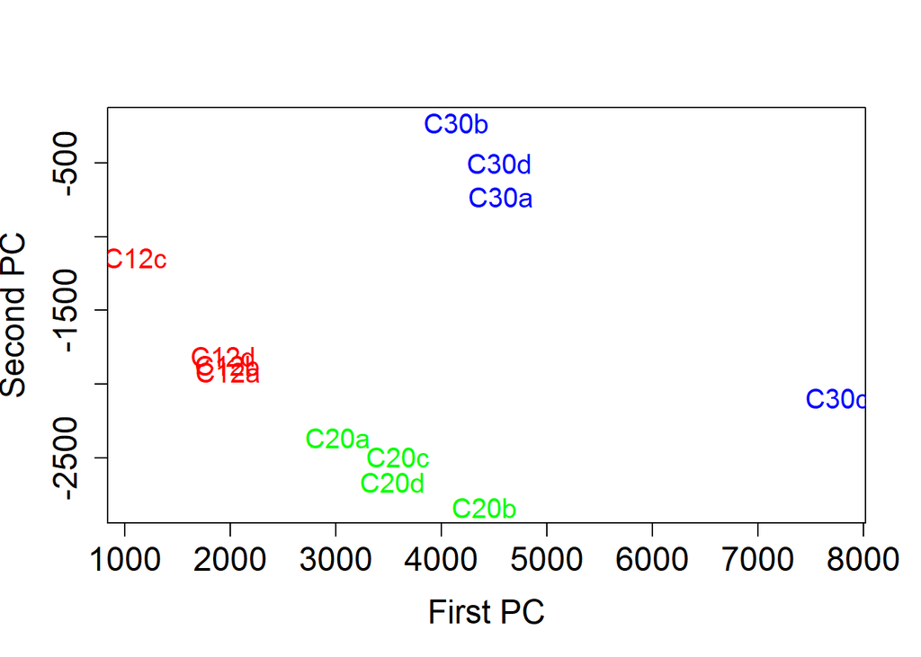

```r
scores.pc_non<-t(gout_yeast_non$rotation)%*%t(combine_yeast_new_T_non-gout_yeast_non$center)
plot(scores.pc_non[1,],scores.pc_non[2,],type="n",xlab="First PC",ylab="Second PC",cex.axis=1.5,cex.lab=1.5)
text(scores.pc_non[1,],scores.pc_non[2,],labels=as.character(colnames(scores.pc_non)),cex=1.25,col=rep(c("red","green","blue"),c(4,4,4)))
```

# Q6

The data “Growth.txt” contains growth rate, lambda, of yeast populations at various different concentration of a limiting nutrient, S. The standard equation governing growth in these conditions is
$$\begin{equation}
\lambda\,=\,\lambda_{\rm max}\frac{S}{K+S}
\end{equation}$$

### a. Plot lambda versus S.

```r
Growth <- read.csv("D:/Desktop/Master_NYU/Statistics in Biology/Final/Growth.txt", sep="")
Growth
```

```
##      S    lambda
## 1    2 0.2413613
## 2    4 0.3739429
## 3    8 0.5534601
## 4   16 0.6940508
## 5   32 0.7269838
## 6   64 0.9770407
## 7  128 1.1780635
## 8    2 0.1057110
## 9    4 0.2161404
## 10   8 0.6002668
## 11  16 0.9260492
## 12  32 0.7594358
## 13  64 1.0088310
## 14 128 1.1780607
## 15   2 0.3484313
## 16   4 0.2583732
## 17   8 0.5663753
## 18  16 0.6418108
## 19  32 1.0035163
## 20  64 0.9664502
## 21 128 1.2438170
```

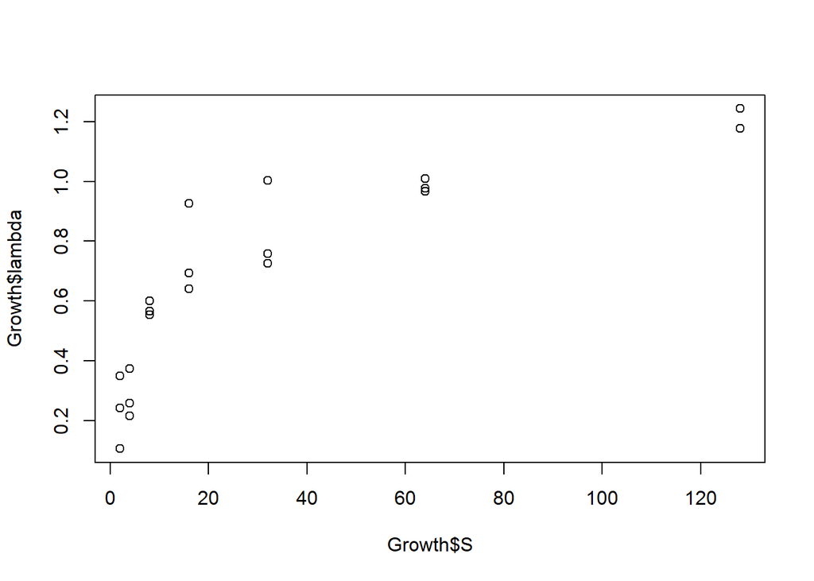

```r
colnames(Growth) <- c("S","lambda")
plot(Growth$S,Growth$lambda)
```

### b. Note that $K$ is the nutrient concentration that gives half-maximal growth rate, and the maximal growth rate $\lambda_{\rm max}$ is the asymptotic growth rate that is approached as $S$ grows very large. Based your plot of the data, what would be reasonable estimates of $K$ and $\lambda_{\rm max}$?

Answer: “Eyeballing”" the data suggests lambda = 1.2, Km = 10 concentration

### c. Use R’s nls function to fit the model in the equation above to the data. Report the results of the model fitting by using the summary function on the output of nls. Add a smooth line to you plot above which is lambda according to your best-fit model

```r
fit.out_growth <-nls(lambda~lambda.max*S/(K.m+S),start=list(lambda.max=1.2,K.m=10),data=Growth)
summary(fit.out_growth)
```

```
##
## Formula: lambda ~ lambda.max * S/(K.m + S)
##
## Parameters:
##            Estimate Std. Error t value Pr(>|t|)
## lambda.max  1.21393    0.05969  20.337 2.35e-14 ***
## K.m        10.72313    1.83560   5.842 1.26e-05 ***
## ---
## Signif. codes:  0 '***' 0.001 '**' 0.01 '*' 0.05 '.' 0.1 ' ' 1
##
## Residual standard error: 0.105 on 19 degrees of freedom
##
## Number of iterations to convergence: 4
## Achieved convergence tolerance: 3.715e-06
```

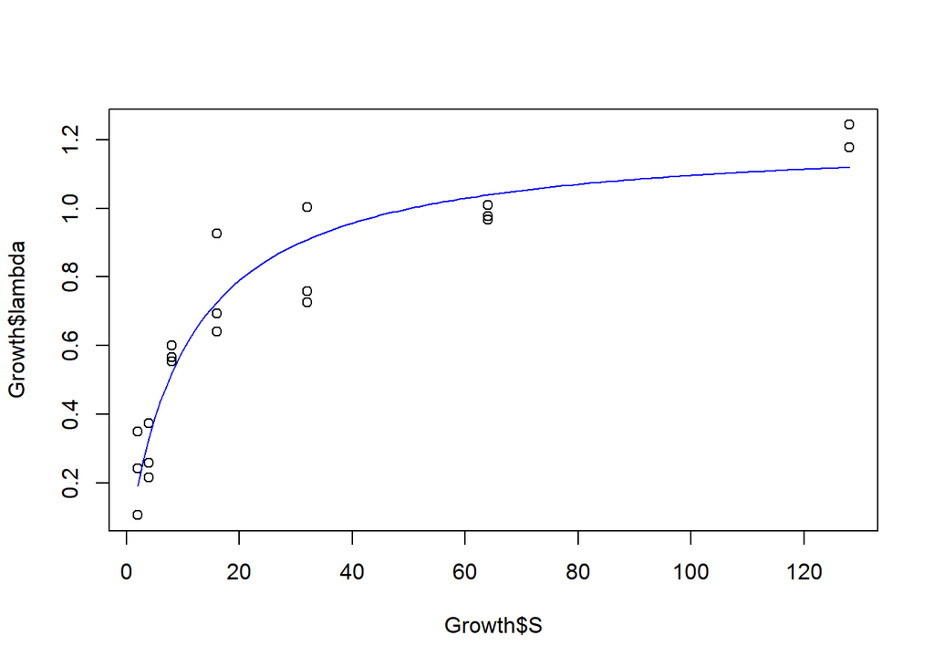

```r
plot(Growth$S,Growth$lambda)
lines(seq(min(Growth$S),max(Growth$S),length.out=127),predict(fit.out_growth,list(S=seq(min(Growth$S),max(Growth$S)))), col="blue",lwd=1)
```

### d. The fitted parameters lambda.max and K are maximum likelihood estimates under the condition that the noise in lambda is additive with zero mean and constant variance. Plot residual versus fitted values for your model. Does it appear that constant variance is a reasonable assumption?

Answer:

It means that when you plot the individual error against the predicted value, the variance of the error predicted value should be constant Yes, we should consider our model as constant variance due to the fact that residuals vs Fitted value do have constant variance around y=0.

```r
library(nlstools)
```

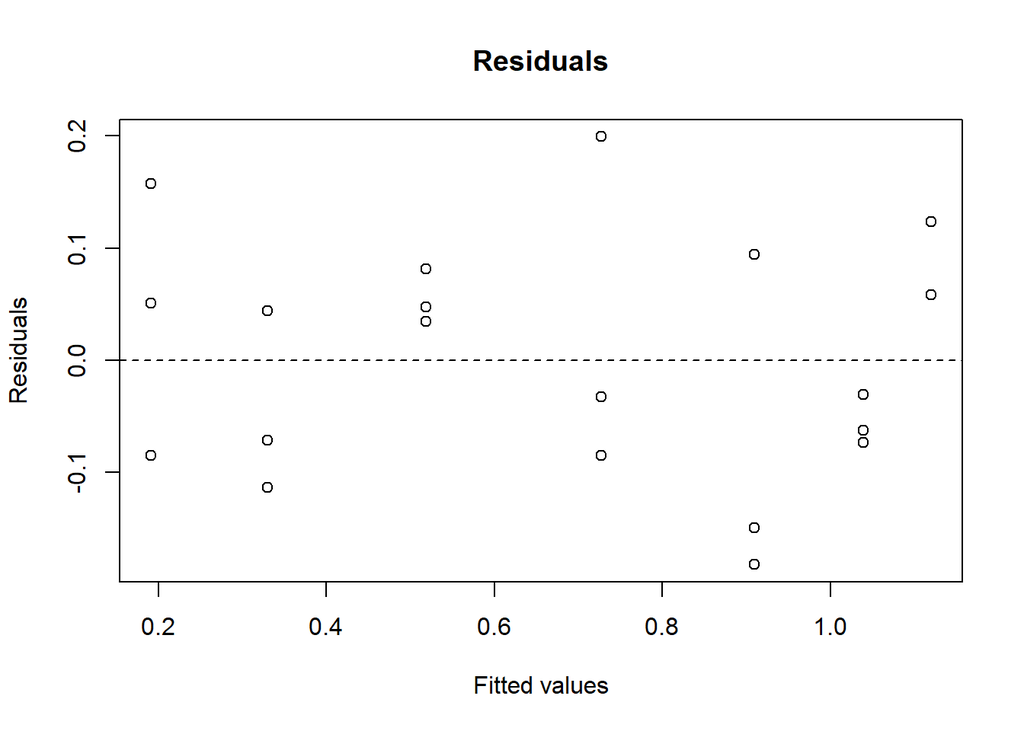

```r
resid.fit<-nlsResiduals(fit.out_growth)
plot(resid.fit,which=1)
```

### e. An alternative way of determining $\lambda_{\rm max}$ and

$K$ is to fit a straight line to $1/\lambda$ versus $1/S$, and use the fact that the intercept is $1/\lambda$ and the slope is $K/\lambda$:
$$\begin{equation}
\frac{1}{\lambda}\,=\,\frac{1}{\lambda_{\rm max}} +
\left(\frac{K}{\lambda_{\rm max}}\right)
\left(\frac{1}{S}\right)
\end{equation}$$
Plot 1/lambda versus 1/S. Define x as 1/S an y as 1/lambda, and perform linear regression with model formula y~x. Add the best fitting line to your plot. Show the first 2 diagnostic plots (residual versus fitted values, and Q-Q plot). Do these data conform to the linear regression model? Explain.

```r
x <- Growth$S^-1
y <- Growth$lambda^-1
Growth_inverse<- data.frame(x,y)
Growth_lm2 <- lm(y~x)
summary(Growth_lm2)
```

```
##
## Call:
## lm(formula = y ~ x)
##
## Residuals:
##    Min     1Q Median     3Q    Max
## -2.784 -0.273 -0.060  0.122  3.806
##
## Coefficients:
##             Estimate Std. Error t value Pr(>|t|)
## (Intercept)   0.8335     0.3465   2.406   0.0265 *
## x             9.6410     1.5878   6.072 7.71e-06 ***
## ---
## Signif. codes:  0 '***' 0.001 '**' 0.01 '*' 0.05 '.' 0.1 ' ' 1
##
## Residual standard error: 1.207 on 19 degrees of freedom
## Multiple R-squared:  0.6599, Adjusted R-squared:  0.642
## F-statistic: 36.87 on 1 and 19 DF,  p-value: 7.709e-06
```

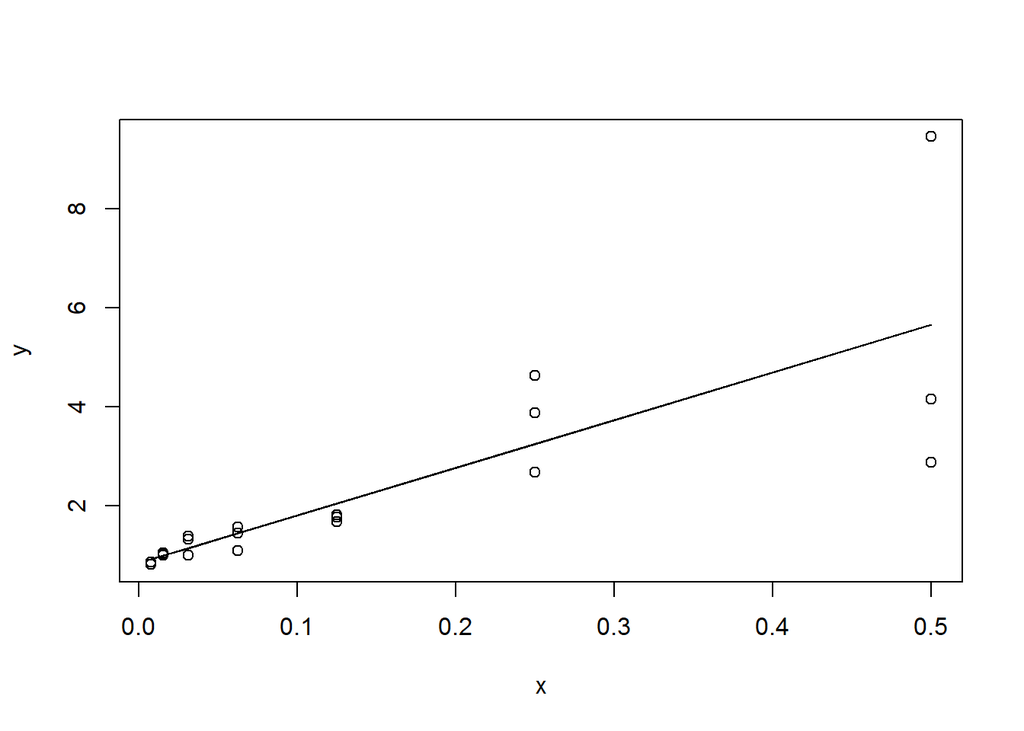

```r
plot(x,y)
lines(x,predict(Growth_lm2))
```

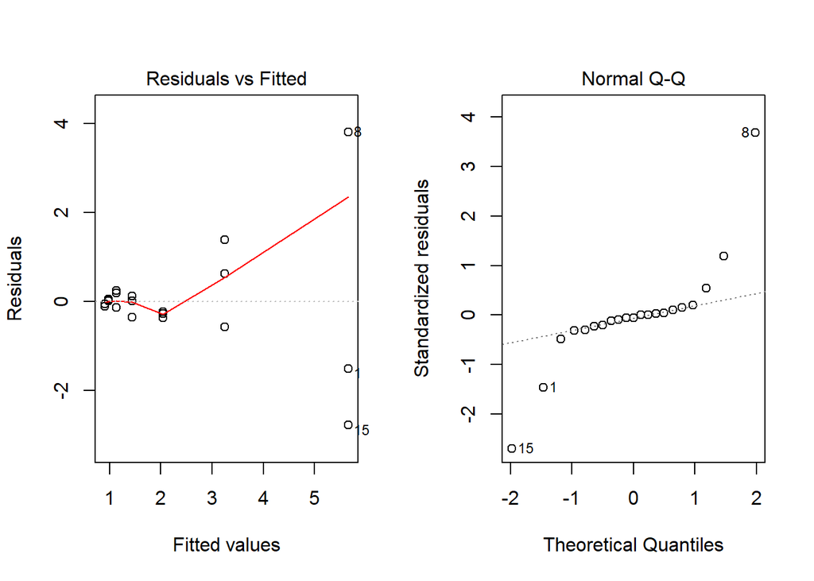

```r
par(mfrow=c(1:2))
plot(Growth_lm2, which =1:2)
```

# Q7

Gene A is tested for the possibility of playing an important role in normal flowering of a laboratory plant. To explore this possibility, 190 plants were grown total, 100 WT, and 90 gene-A knockout (KO), and they were scored for presence (plus) or absence (minus) of a flowering defect. The data were organized in a 2-by-2 table, with row labels, plus and minus, an column labels KO and WT, as follows:

### a. What statistical test is ideal for analyzing such a 2-by-2 contingency table?

Answer:

Both chi-square test and Fisher’s exact test is ideal for analyzing 2-by-2 contigency table. In this case, I will pick Fisher’s exact test due to its expected value.

```r
Plant <-matrix(c(10, 80, 4, 96),nrow = 2,dimnames = list(defect = c("plus", "minus"),Gene = c("KO", "WT")))
Plant
```

```
##        Gene
## defect  KO WT
##   plus  10  4
##   minus 80 96
```

```r
E<- chisq.test(Plant)$expected
E
```

```
##        Gene
## defect         KO        WT
##   plus   6.631579  7.368421
##   minus 83.368421 92.631579
```

```r
chisq.test(Plant,correct = FALSE)
```

```
##
##  Pearson's Chi-squared test
##
## data:  Plant
## X-squared = 3.5094, df = 1, p-value = 0.06102
```

```r
row <- rowSums(Plant)
col <- colSums(Plant)
```

### b. What are $\rm H_0$ and $\rm H_A$?

Answer:

H0: The abnormalities of KO is equal or less than WT  
HA: The abnormalities of KO is higher than WT

### c. Perform this test using the appropriate built-in R function. Report a p-value and a 99% confidence interval. Does this confidence interval include the value 1?

Answer:

Yes, it include the value 1

```r
p.val<-phyper(q=Plant[1,1]-1,m=col[1], n=col[2], k=row[1],lower.tail=FALSE)
p.val
```

```
## [1] 0.05469505
```

```r
fisher.test(Plant, alternative = "greater",conf.level = 0.99)
```

```
##
##  Fisher's Exact Test for Count Data
##
## data:  Plant
## p-value = 0.0547
## alternative hypothesis: true odds ratio is greater than 1
## 99 percent confidence interval:
##  0.6718775       Inf
## sample estimates:
## odds ratio
##   2.983307
```

### d. Write the R code to perform a Monte Carlo version of this statistical test involving 10,000 trials in a . In each trial, draw a sample (without replacement) of size 14 from c(rep(“KO”,90),rep(“WT”,100)), and record the number of “KO” values in this sample. Your empirical p-value is the fraction of trials in which the number “KO” values is greater than or equal to the observed value, 10. Report this empirical p-value and compare it tho the p-value you obtained in part (c) above.

Answer:

The p-value calculated by Fisher’s exact test is almost the same as Monte Carlo simulation. Both p-values are not small enough to reject the null hypothesis.

```r
ALL <- c(rep("KO",90),rep("WT",100))
number<-0
for (i in 1:10000){
  X<-sum(sample(ALL,size=row[1])=='KO',replace = FALSE)
  if(X>=10){
    number <- number+1
  }
}
print(number/10000)
```

```
## [1] 0.0555
```

### e. Why do the Monte Carlo simulations in part (d) test the null hypothesis?

Answer:

In null hypothesis, we assume that the abnormalities are the same for WT and KO. While in Monte-Carlo method, we randomly assigned plus to KO and WT. If KO get pluses more than 10 times which higher than the data. We can assume it as a extreme case and calculate the occurences of extreme case. Then, we divided the number by total (10000) to get p-value. If the p-value is less than 0.05, there is a confidence that we can reject the null hypothesis.

**End of assignment**